# Section 11: K-Means Clustering

Pablo Arés Gastesi

2026-07-07

# 1 Introduction

Like hierarchical clustering (Section 12), K-means is **unsupervised**: there is no response variable, and the goal is simply to group similar observations. The two methods differ in approach. Hierarchical clustering builds a full nested tree and lets you cut it at any height afterwards. **K-means** instead partitions the data directly into a *fixed* number of disjoint clusters $K$, chosen in advance, with no hierarchy at all.

## 1.1 The objective

K-means looks for a partition of the data into disjoint clusters $C_1, C_2, \ldots, C_K$ that makes each cluster as internally “uniform” as possible — formally, that minimises the **total within-cluster variation**:

$$\min_{C_1,\ldots,C_K} \sum_{i=1}^{K} W(C_i)$$

where $W(C_i)$ measures how spread out the points inside cluster $C_i$ are. The usual choice is the average squared Euclidean distance between all pairs of points in the cluster:

$$W(C) = \frac{1}{|C|} \sum_{x \neq y \in C} \lVert x - y \rVert^2$$

with $|C|$ the number of points in $C$. So the full problem is

$$\min_{C_1,\ldots,C_K} \sum_{i=1}^{K} \frac{1}{|C_i|} \sum_{x \neq y \in C_i} \lVert x - y \rVert^2$$

## 1.2 The algorithm

K-means solves this (approximately) by iterating a simple two-step procedure, starting from an arbitrary initial partition:

1. Compute the **centre** (mean) of each current cluster.
2. Reassign every point to the cluster whose centre is closest.

Repeating these two steps always reduces (or leaves unchanged) the total within-cluster variation, and the algorithm stops once no point changes cluster. The catch is that this only finds a **local** minimum, and *which* local minimum it lands on depends entirely on the (random) starting partition. This is why in practice we always run K-means from many different random starts and keep the best result — R’s `kmeans()` does this automatically via its `nstart` argument.

# 2 A basic example

We simulate 100 random, standardised points and cluster them with $K = 2$. As with every distance-based method in this course, standardising first matters — otherwise the clustering would depend on the arbitrary units of each variable.

```r
set.seed(1234)
x <- scale(runif(100, min = -3, max = 3))
y <- scale(runif(100, min = 0, max = 5))
sim_data <- data.frame(x, y)

km_one <- kmeans(sim_data, centers = 2, nstart = 1)
```

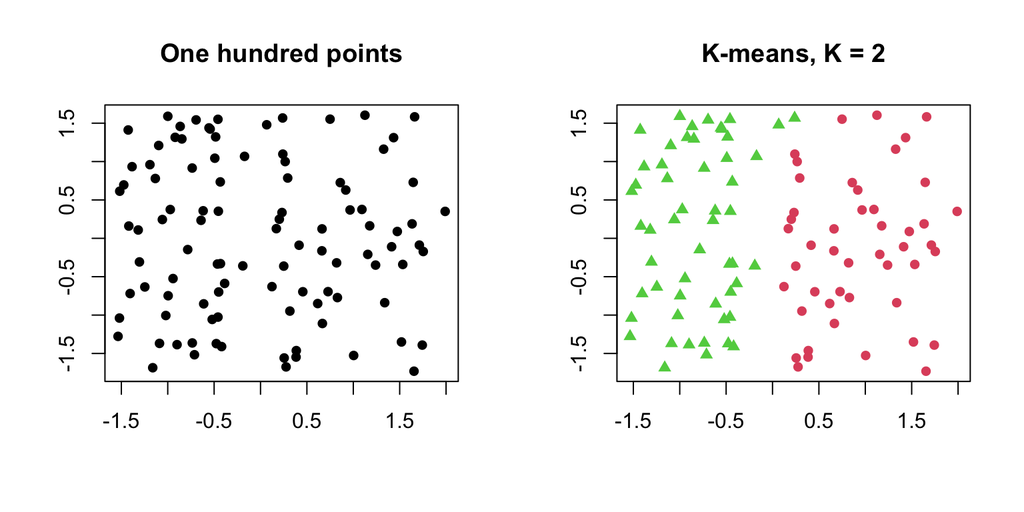

Figure 2.1: Raw data (left) and K-means with K = 2, one random start (right)

```r
par(mfrow = c(1, 2))
plot(sim_data$x, sim_data$y, pch = 16, xlab = "", ylab = "", main = "One hundred points")
plot(sim_data$x, sim_data$y, col = km_one$cluster + 1, pch = km_one$cluster + 15,
    xlab = "", ylab = "", main = "K-means, K = 2")
```

```r
par(mfrow = c(1, 1))
```

## 2.1 Sensitivity to the starting partition

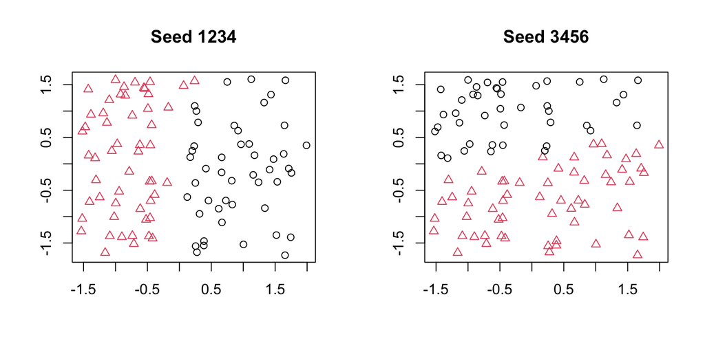

Figure 2.2: Two different random starts, same K = 2 — the results disagree

```r
set.seed(3456)
km_two <- kmeans(sim_data, centers = 2, nstart = 1)

par(mfrow = c(1, 2))
plot(sim_data$x, sim_data$y, col = km_one$cluster, pch = km_one$cluster,
    xlab = "", ylab = "", main = "Seed 1234")
plot(sim_data$x, sim_data$y, col = km_two$cluster, pch = km_two$cluster,
    xlab = "", ylab = "", main = "Seed 3456")
```

```r
par(mfrow = c(1, 1))
```

```r
cat("Seed 1234, total within-cluster SS:", km_one$tot.withinss, "\n")
```

```
## Seed 1234, total within-cluster SS: 120.8179
```

```r
cat("Seed 3456, total within-cluster SS:", km_two$tot.withinss, "\n")
```

```
## Seed 3456, total within-cluster SS: 122.617
```

The two starting points give visibly different partitions of the *same* data (unsurprising, since this data was simulated with no real clusters in it), and correspondingly different total within-cluster sums of squares — lower is better, so seed 1234 happens to give the slightly better split here. Comparing every possible starting partition by hand clearly does not scale, which is exactly what `nstart` is for:

```r
km_two_final <- kmeans(sim_data, centers = 2, nstart = 20)
```

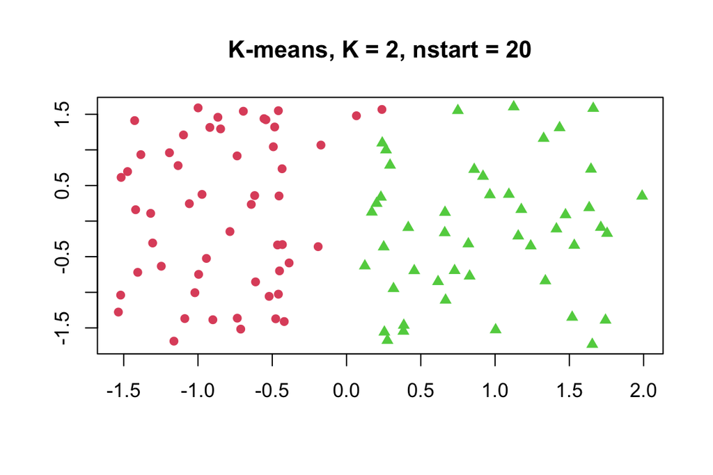

Figure 2.3: K-means with 20 random starts, keeping the best result

```r
plot(sim_data$x, sim_data$y, col = km_two_final$cluster + 1, pch = km_two_final$cluster + 15,
    xlab = "", ylab = "", main = "K-means, K = 2, nstart = 20")
```

`nstart = 20` runs the whole algorithm 20 times from 20 different random partitions and automatically keeps the one with the lowest total within-cluster sum of squares — removing the guesswork above entirely.

## 2.2 Does the number of starts matter for larger K?

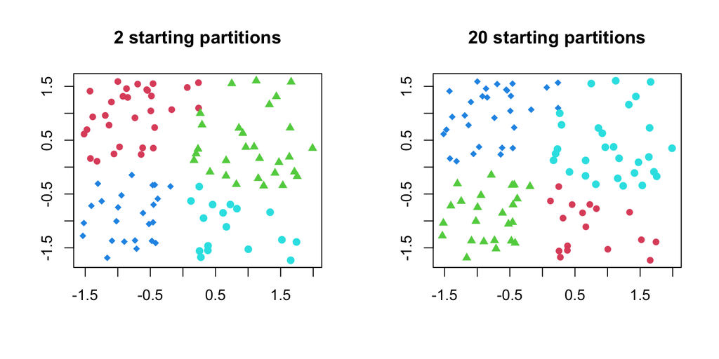

Figure 2.4: 4 clusters: 2 starting partitions (left) vs. 20 (right)

```r
km_few_starts  <- kmeans(sim_data, centers = 4, nstart = 2)
km_many_starts <- kmeans(sim_data, centers = 4, nstart = 20)

par(mfrow = c(1, 2))
plot(sim_data$x, sim_data$y, col = km_few_starts$cluster + 1, pch = km_few_starts$cluster + 15,
    xlab = "", ylab = "", main = "2 starting partitions")
plot(sim_data$x, sim_data$y, col = km_many_starts$cluster + 1, pch = km_many_starts$cluster + 15,
    xlab = "", ylab = "", main = "20 starting partitions")
```

```r
par(mfrow = c(1, 1))
```

With more clusters, there are more ways for the algorithm to get stuck in a poor local minimum, so the gap between few and many starting partitions tends to widen — another reason to always use a generous `nstart` in practice (the R default is only 1).

# 3 Choosing the number of clusters

Unlike hierarchical clustering, K-means requires us to fix $K$ *before* fitting. One common heuristic: fit K-means for a range of values of $K$ and plot the total within-cluster sum of squares against $K$, looking for an “elbow” where adding more clusters stops helping much.

```r
sum_squares <- vector(mode = "double", length = 8)
for (i in 2:9) {
  km_tmp <- kmeans(sim_data, centers = i, nstart = 20)
  sum_squares[i - 1] <- km_tmp$tot.withinss
}
```

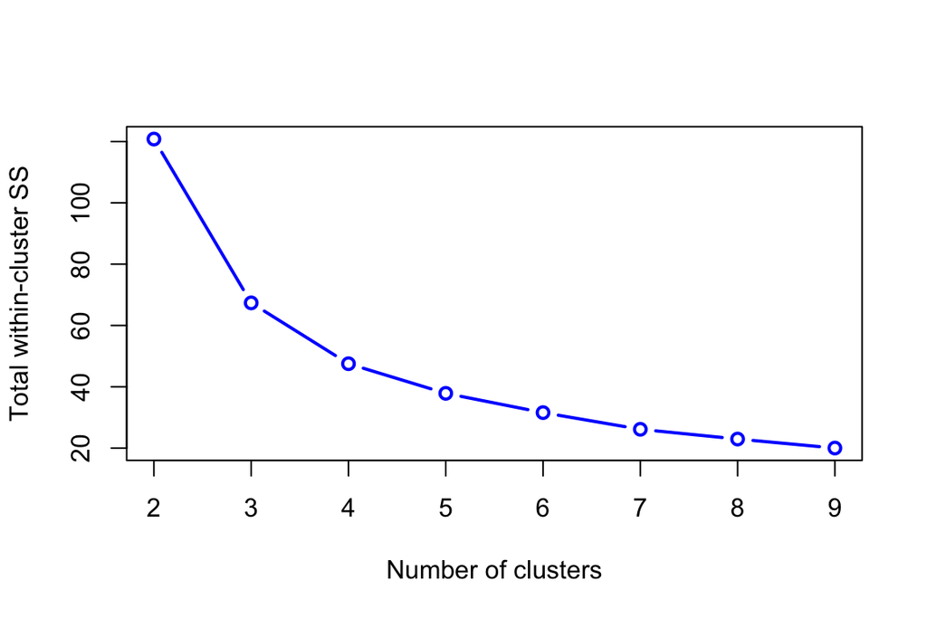

Figure 3.1: Total within-cluster sum of squares vs. number of clusters

```r
plot(2:9, sum_squares, type = "b", col = "blue", lwd = 2,
    xlab = "Number of clusters", ylab = "Total within-cluster SS")
```

Total within-cluster variation always decreases as $K$ grows (in the extreme, $K = n$ gives zero variation, one point per cluster) — so this plot never has a true minimum to find. The point is to look for diminishing returns: past a certain $K$, adding another cluster barely reduces the total further. With only two simulated, essentially unstructured variables here, there isn’t a compelling elbow to point to — a reminder that this heuristic works better with real structure in higher-dimensional data, which is exactly our next example.

# 4 A real example: `USArrests`

We cluster US states by their standardised violent-crime statistics (`Murder`, `Assault`, `UrbanPop`, `Rape`):

```r
df_usarrests <- scale(USArrests)
colnames(df_usarrests)
```

```
## [1] "Murder"   "Assault"  "UrbanPop" "Rape"
```

```r
km_usarrests <- kmeans(df_usarrests, centers = 4, nstart = 20)
km_usarrests
```

```
## K-means clustering with 4 clusters of sizes 13, 13, 16, 8
##
## Cluster means:
##       Murder    Assault   UrbanPop        Rape
## 1  0.6950701  1.0394414  0.7226370  1.27693964
## 2 -0.9615407 -1.1066010 -0.9301069 -0.96676331
## 3 -0.4894375 -0.3826001  0.5758298 -0.26165379
## 4  1.4118898  0.8743346 -0.8145211  0.01927104
##
## Clustering vector:
##        Alabama         Alaska        Arizona       Arkansas     California
##              4              1              1              4              1
##       Colorado    Connecticut       Delaware        Florida        Georgia
##              1              3              3              1              4
##         Hawaii          Idaho       Illinois        Indiana           Iowa
##              3              2              1              3              2
##         Kansas       Kentucky      Louisiana          Maine       Maryland
##              3              2              4              2              1
##  Massachusetts       Michigan      Minnesota    Mississippi       Missouri
##              3              1              2              4              1
##        Montana       Nebraska         Nevada  New Hampshire     New Jersey
##              2              2              1              2              3
##     New Mexico       New York North Carolina   North Dakota           Ohio
##              1              1              4              2              3
##       Oklahoma         Oregon   Pennsylvania   Rhode Island South Carolina
##              3              3              3              3              4
##   South Dakota      Tennessee          Texas           Utah        Vermont
##              2              4              1              3              2
##       Virginia     Washington  West Virginia      Wisconsin        Wyoming
##              3              3              2              2              3
##
## Within cluster sum of squares by cluster:
## [1] 19.922437 11.952463 16.212213  8.316061
##  (between_SS / total_SS =  71.2 %)
##
## Available components:
##
## [1] "cluster"      "centers"      "totss"        "withinss"     "tot.withinss"
## [6] "betweenss"    "size"         "iter"         "ifault"
```

With four variables we can no longer just plot the raw data — the printed summary is our main tool here. `kmeans()` reports, among other things, the **cluster means** (the profile of each cluster on every variable), the **clustering vector** (which cluster each state landed in), and the **within-cluster sum of squares by cluster**.

## 4.1 Interpreting `between_SS / total_SS`

`between_SS` is the total sum of squares minus the within-cluster sum of squares — the variation *explained* by separating the data into clusters, as opposed to variation left *unexplained* inside each cluster. The ratio `between_SS / total_SS` (here about 71%) is a rough measure of how much the clustering is telling us:

- If it were 0%, `between_SS` would be zero — there would effectively be only one cluster (no separation at all).
- If it were 100%, `within_SS` would be zero — every point would be its own cluster, which is technically “perfect” but useless.

```r
cat("Between SS / Total SS:",
   round(100 * km_usarrests$betweenss / km_usarrests$totss, 1), "%\n")
```

```
## Between SS / Total SS: 71.2 %
```

## 4.2 A more systematic way to choose K

Rather than eyeballing an elbow plot by hand, `factoextra::fviz_nbclust()` automates it:

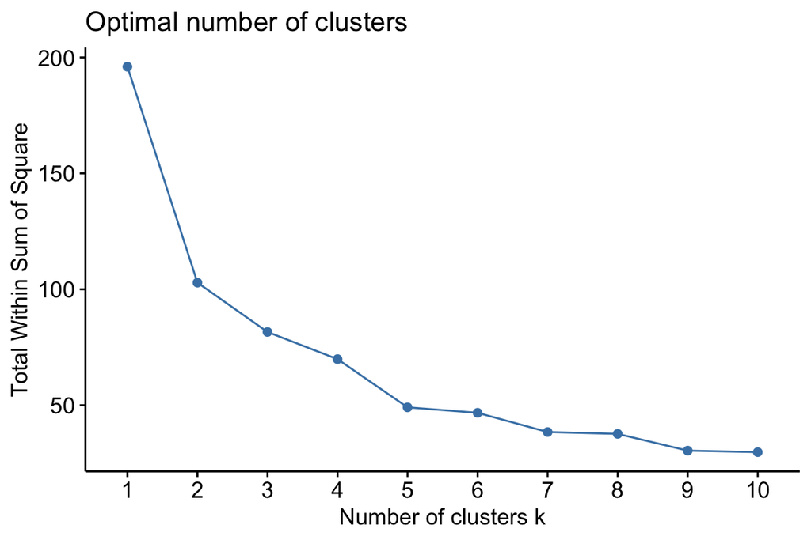

Figure 4.1: Total within-cluster SS vs. K for USArrests, via fviz_nbclust

```r
fviz_nbclust(df_usarrests, FUNcluster = kmeans, method = "wss")
```

# 5 Visualising K-means results

With more than two variables we can’t plot the raw clusters directly, but `factoextra::fviz_cluster()` projects the data onto its first two principal components (Section 13) and colours points by cluster, which gets us a usable 2-D picture even in higher dimensions. Since `df_usarrests` is already standardised, there’s no need to ask `fviz_cluster()` to standardise again.

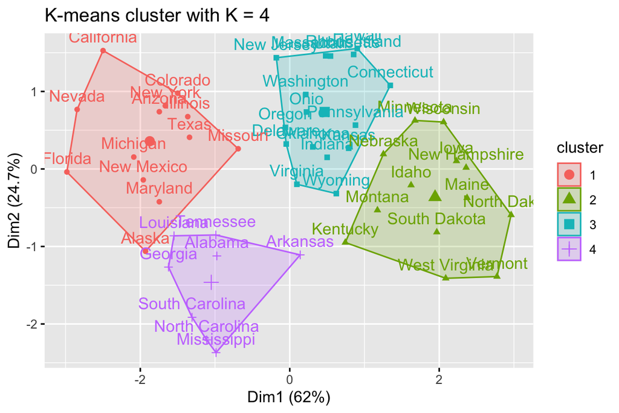

Figure 5.1: K-means clusters (K = 4) projected onto the first two principal components

```r
fviz_cluster(km_usarrests, data = df_usarrests, main = "K-means cluster with K = 4")
```

## 5.1 Comparing several values of K side by side

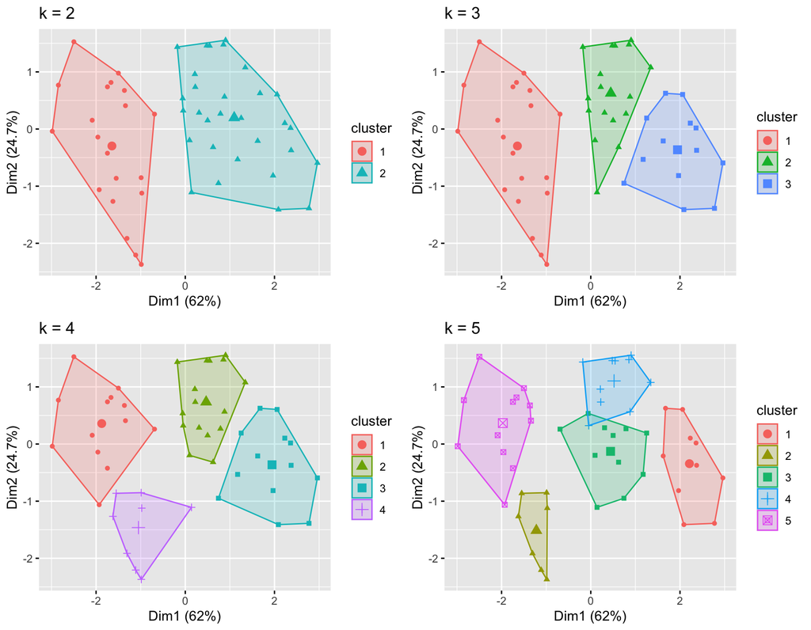

Figure 5.2: K-means clusters for K = 2, 3, 4, 5

```r
k2 <- kmeans(df_usarrests, centers = 2, nstart = 20)
k3 <- kmeans(df_usarrests, centers = 3, nstart = 20)
k4 <- kmeans(df_usarrests, centers = 4, nstart = 20)
k5 <- kmeans(df_usarrests, centers = 5, nstart = 20)

p2 <- fviz_cluster(k2, geom = "point", data = df_usarrests) + ggtitle("k = 2")
p3 <- fviz_cluster(k3, geom = "point", data = df_usarrests) + ggtitle("k = 3")
p4 <- fviz_cluster(k4, geom = "point", data = df_usarrests) + ggtitle("k = 4")
p5 <- fviz_cluster(k5, geom = "point", data = df_usarrests) + ggtitle("k = 5")

grid.arrange(p2, p3, p4, p5, nrow = 2)
```

## 5.2 Visualising the raw distances

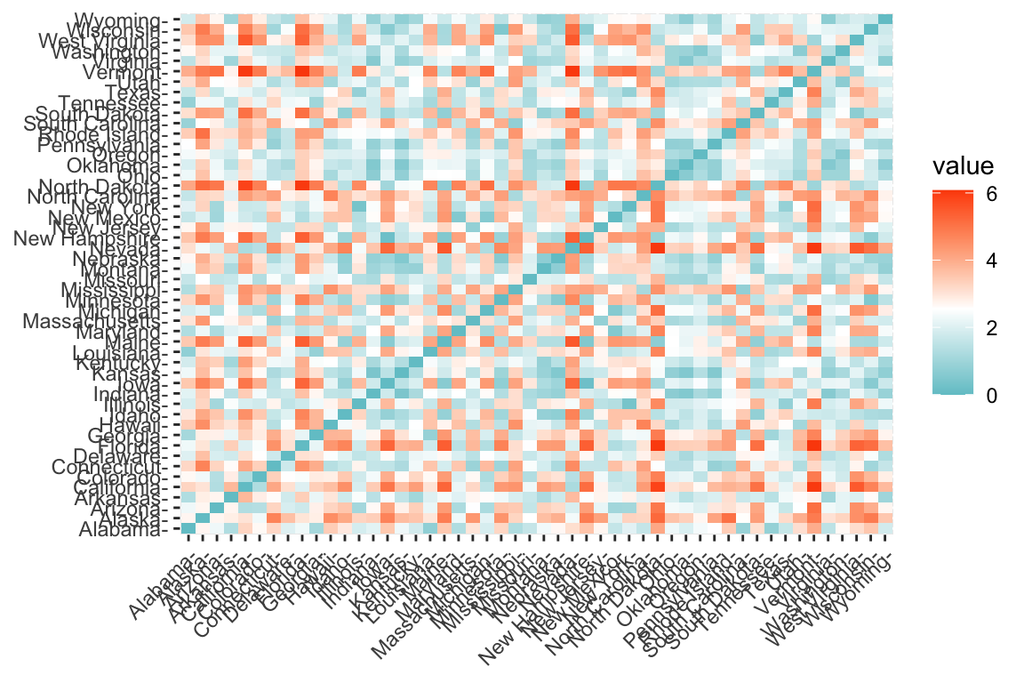

Figure 5.3: Pairwise distances between US states

```r
state_dist <- get_dist(df_usarrests)
fviz_dist(state_dist, gradient = list(low = "#00AFBB", mid = "white", high = "#FC4E07"))
```

# 6 Related clustering methods

K-means, as defined here, relies on **squared Euclidean distance**, which means it is quite sensitive to outliers — one extreme point can pull a cluster’s centre a long way. Two related methods address this:

- **K-medians**: uses the median instead of the mean to define each cluster’s centre, which is far less sensitive to outliers.
- **K-medoids** (via the **PAM** — Partitioning Around Medoids — algorithm, `cluster::pam()`): restricts each cluster’s “centre” to be an actual data point (a medoid) rather than an average, which also limits the influence of any single outlier and works with any distance measure, not just Euclidean.

# 7 Summary

- K-means partitions data into a **fixed number $K$** of clusters chosen in advance, by minimising total within-cluster squared-distance variation.
- The algorithm (alternately updating cluster centres and reassigning points) only guarantees a **local** minimum, so it should always be run from many random starts (`nstart`, generously set — the default of 1 is too low for real use) and the best result kept.
- As with every distance-based method in this course, **standardise** variables first unless they are already on comparable scales.
- Choosing $K$ is not automatic: an elbow plot of total within-cluster SS vs. $K$ (or `factoextra::fviz_nbclust()`) is a common heuristic, but total within-cluster SS always decreases as $K$ grows, so there is no true minimum to find — only diminishing returns to look for.
- `between_SS / total_SS` measures how much structure the clustering is capturing; extremes at 0% (one cluster) or 100% (one point per cluster) are both uninformative.
- K-medians and K-medoids (PAM) are more outlier-robust alternatives when Euclidean distance and cluster means are not appropriate.

| Concept | Function | Notes |
| --- | --- | --- |
| Fit K-means | `kmeans(data, centers = K, nstart = ...)` | always use a generous `nstart`; default is 1 |
| Total within-cluster SS | `fit$tot.withinss` | lower is better, for a fixed $K$ |
| Between/total SS ratio | `fit$betweenss / fit$totss` | rough measure of how informative the clustering is |
| Choose K (elbow) | `factoextra::fviz_nbclust(data, kmeans, method = "wss")` | automates the by-hand elbow plot |
| Visualise clusters (p > 2) | `factoextra::fviz_cluster(fit, data = ...)` | projects onto the first two principal components |
| Pairwise distance heatmap | `factoextra::fviz_dist(get_dist(data))` | inspect raw structure before clustering |
| Outlier-robust alternative | `cluster::pam(data, k)` | k-medoids: centres restricted to actual data points |

Key takeaway: K-means and hierarchical clustering solve the same kind of problem (find groups of similar observations with no labels to guide us) in different ways — K-means commits to a fixed $K$ up front and searches for the best partition directly, while hierarchical clustering builds the whole nested structure and leaves the choice of how many groups to keep for later. Neither approach can be “validated” the way a supervised model can; the number of clusters and their usefulness are judged by heuristics (elbow plots, the between/total SS ratio) and, ultimately, by whether the groups found make sense given domain knowledge.